# Recalling Words

```r
# Play the chunk above and this one to get the data into your Console
View(Friendly)
?Friendly
```

#### Background

Many teachers and other educators are interested in understanding how to best deliver new content to students. In general, they have two choices of how to do this.

1. The Meshed Approach
   - Deliver new content while simultaneously reviewing previously understood content.
2. The Before Approach
   - Deliver new content after fully reviewing previously understood content.

A study was performed to determine whether the *Meshed* or *Before* approaches to delivering content had any positive benefits on memory recall.

##### The Experiment (click to view)

# Questions and Hypotheses

- The question: Is the before and after method for remembering better than just the control?
- The null hypothesis: There is no difference between the effectiveness of standard free recall (control) and the other methods.
- The alternative hypothesis: One of the other methods is better than the standard free recall (control) method.

# Analysis

### qq test to check the normality of the data:

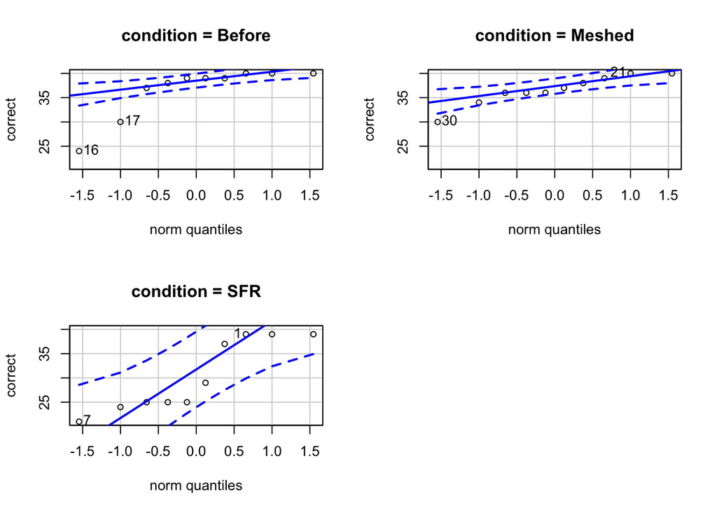

```r
qqPlot(correct ~ condition, data = Friendly)
```

### First Wilcox Rank-Sum test seeing if the “before” method is better than the control

```r
a <- wilcox.test(Friendly$correct[Friendly$condition == "Before"],Friendly$correct[Friendly$condition == "SFR"] ,mu = 0, alternative = "greater")

pander(a)
```

Wilcoxon rank sum test with continuity correction: `Friendly$correct[Friendly$condition == "Before"]` and `Friendly$correct[Friendly$condition == "SFR"]`

| Test statistic | P value | Alternative hypothesis |
| --- | --- | --- |
| 76.5 | 0.02278 * | greater |

Using an alpha value of 0.05 we see that we can accept the alternative hypothesis that the “before” method was better than the control because our p value is under 0.05.

### Second Wilcox Rank-Sum test seeing if the “meshed” method is better than the control

```r
a <- wilcox.test(Friendly$correct[Friendly$condition == "Meshed"],Friendly$correct[Friendly$condition == "SFR"] ,mu = 0, alternative = "greater")

pander(a)
```

Wilcoxon rank sum test with continuity correction: `Friendly$correct[Friendly$condition == "Meshed"]` and `Friendly$correct[Friendly$condition == "SFR"]`

| Test statistic | P value | Alternative hypothesis |
| --- | --- | --- |
| 72 | 0.05075 | greater |

It looks like our p-value is just over 0.05 so we have to reject the alternative hypothesis that the “meshed” method is better than the control method. It also seems like we can stop here since we accepted that the “before” method was better than the control.

# Graphical Summary

I will show a box-plot combined with a jitter plot to show the distribution of the data. This will give us the spread of the data and more valueable information than just a boxplot would show especially for so few data points.

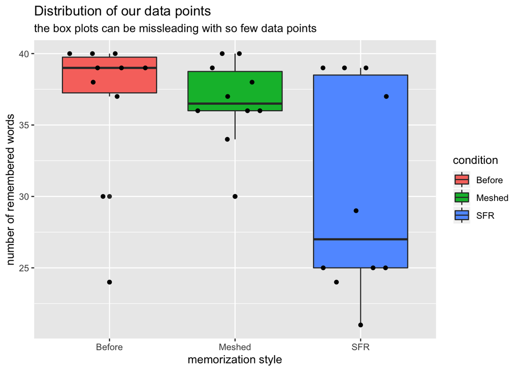

```r
ggplot(data = Friendly) +
  geom_boxplot(mapping = aes(x = condition, y = correct, fill = condition)) +
  geom_quasirandom(mapping = aes(x = condition, y = correct)) +
  labs(title = "Distribution of our data points", subtitle = "the box plots can be missleading with so few data points", x = "memorization style", y = "number of remembered words")
```

# Interpretation

It seems like there’s a really high 75th percentile for the SFR random control method that is comparable to the other methods but actually looking at the data there are only a few points up there and they’re very spread out compared to the other memorization methods in which more data points are higher up and grouped together. This shows that the other methods look more effective as a memorization technique particularly the “before” method which we proved in the analysis.

# Conclusion